# Study of wheather events in public health and economics

Marcelo Ortiz de Santana

January 17, 2016

```r
library("ggplot2")
library("scales")
library("Rmisc")
```

## Synopsis

This study aims understand the impact of weather events on the public health and economics.

The data used are available from National Oceanic and Atmospheric Administration (NOAA).

The data has the type of the weather event, the state and county which the event occurred, the number of injuries and fatalities and the value in dollars of property and crop damages.

In this study, we explore only the number of injuries, fatalities, damage of properties and crops and the type of weather event.

## Data Processing

```r
data <- read.csv("data/repdata-data-StormData.csv.bz2")
```

The data file used has aproximally 46.8989792Mb. The data contains 902297 rows and 37 columns.

The values of damages in properties and crop are scalled by abbreviations (“K” for thousands, “M” for millions, and “B” for billions). The follow steps transform the values to same scale:

```r
data$PROPDMG_MODIF <- 0
data[data$PROPDMGEXP == "K",]$PROPDMG_MODIF <- data[data$PROPDMGEXP == "K", c("PROPDMG")] * 1e3
data[data$PROPDMGEXP == "M",]$PROPDMG_MODIF <- data[data$PROPDMGEXP == "M", c("PROPDMG")] * 1e6
data[data$PROPDMGEXP == "B",]$PROPDMG_MODIF <- data[data$PROPDMGEXP == "B", c("PROPDMG")] * 1e9

data$CROPDMG_MODIF <- 0
data[data$CROPDMGEXP == "K",]$CROPDMG_MODIF <- data[data$CROPDMGEXP == "K", c("CROPDMG")] * 1e3
data[data$CROPDMGEXP == "M",]$CROPDMG_MODIF <- data[data$CROPDMGEXP == "M", c("CROPDMG")] * 1e6
data[data$CROPDMGEXP == "B",]$CROPDMG_MODIF <- data[data$CROPDMGEXP == "B", c("CROPDMG")] * 1e9
```

## Results

### Public health impacts

Here we indicate the events most harmful for public health grouped by event type. We consider the fatalities and injuries in that study.

```r
data_most_harm_health_evt <- aggregate(FATALITIES + INJURIES ~ EVTYPE, data=data, FUN=sum)
colnames(data_most_harm_health_evt) <- c("EVTYPE", "HEALTH_DAMAGE")
data_most_harm_health_evt <- data_most_harm_health_evt[data_most_harm_health_evt$HEALTH_DAMAGE > 0, ]
data_most_harm_health_evt_sort <- data_most_harm_health_evt[order(-data_most_harm_health_evt$HEALTH_DAMAGE),]
data_most_harm_health_evt_sort <- data_most_harm_health_evt_sort[0:30,]

head(data_most_harm_health_evt_sort, n=30)
```

```
##                 EVTYPE HEALTH_DAMAGE
## 830            TORNADO         96979
## 123     EXCESSIVE HEAT          8428
## 854          TSTM WIND          7461
## 164              FLOOD          7259
## 452          LIGHTNING          6046
## 269               HEAT          3037
## 147        FLASH FLOOD          2755
## 424          ICE STORM          2064
## 759  THUNDERSTORM WIND          1621
## 972       WINTER STORM          1527
## 354          HIGH WIND          1385
## 238               HAIL          1376
## 406  HURRICANE/TYPHOON          1339
## 304         HEAVY SNOW          1148
```

[output cut: 16 more lines]

```r
breaks <- pretty(data_most_harm_health_evt_sort$HEALTH_DAMAGE, n = 25)
p1 <- ggplot(data=data_most_harm_health_evt_sort, aes(x=reorder(EVTYPE,HEALTH_DAMAGE), y=HEALTH_DAMAGE)) + scale_y_discrete(breaks=breaks) +
  geom_bar(stat="identity") + theme(axis.text.x = element_text(angle = 90)) + coord_flip() + labs(title = "Bar plot of most harmful events for public health", x="Event", y="Number of occurrences")
```

Grouping the data by state, the following states are most affected.

```r
data_most_harm_health_st <- aggregate(FATALITIES + INJURIES ~ STATE, data=data, FUN=sum)
colnames(data_most_harm_health_st) <- c("STATE", "HEALTH_DAMAGE")
data_most_harm_health_st <- data_most_harm_health_st[data_most_harm_health_st$HEALTH_DAMAGE > 0, ]
data_most_harm_health_st_sort <- data_most_harm_health_st[order(-data_most_harm_health_st$HEALTH_DAMAGE),]
data_most_harm_health_st_sort <- data_most_harm_health_st_sort[0:30,]

head(data_most_harm_health_st_sort, n=30)
```

```
##    STATE HEALTH_DAMAGE
## 63    TX         19033
## 37    MO          9752
## 2     AL          9526
## 48    OH          7515
## 38    MS          7230
## 20    IL          6984
## 13    FL          6664
## 49    OK          6168
## 5     AR          6080
## 62    TN          5723
## 14    GA          5388
## 21    IN          5111
## 35    MI          4984
## 51    PA          4069
```

[output cut: 16 more lines]

```r
breaks <- pretty(data_most_harm_health_st_sort$HEALTH_DAMAGE, n = 25)
p2 <- ggplot(data=data_most_harm_health_st_sort, aes(x=reorder(STATE,HEALTH_DAMAGE), y=HEALTH_DAMAGE)) + scale_y_discrete(breaks=breaks) +
  geom_bar(stat="identity") + theme(axis.text.x = element_text(angle = 90)) + coord_flip() + labs(title = "Bar plot of most harmful events for public health by state", x="State", y="Number of occurrences")
```

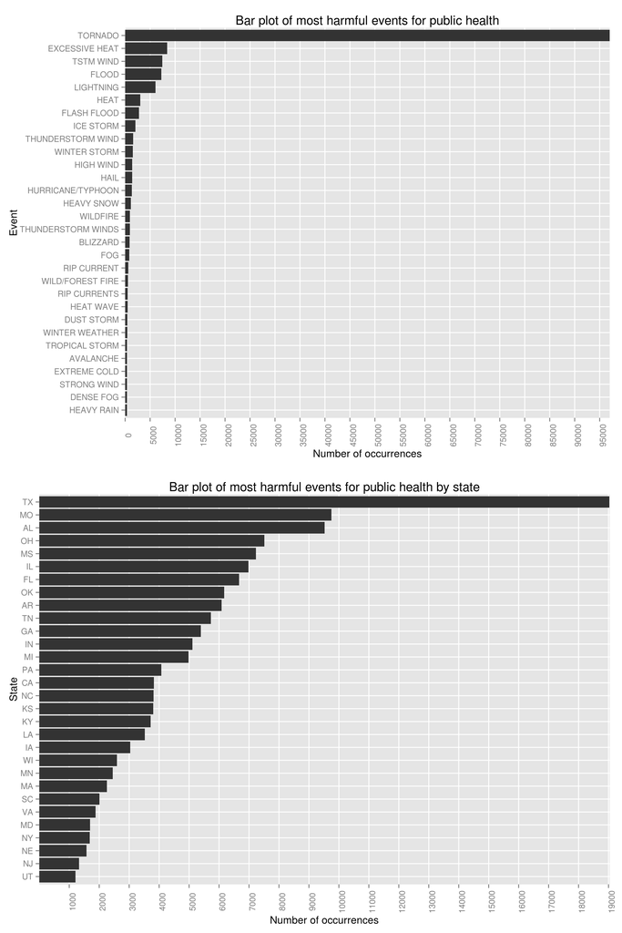

```r
multiplot(p1, p2, cols = 1)
```

### Economics impact

We do the same study for economics. The following plot show the damages in dollars of property and crop, grouped by events.

```r
most_damage_econ_evt <- aggregate(PROPDMG_MODIF + CROPDMG_MODIF ~ EVTYPE, data=data, FUN=sum)
colnames(most_damage_econ_evt) <- c("EVTYPE", "ECON_DAMAGE")
most_damage_econ_evt <- most_damage_econ_evt[most_damage_econ_evt$ECON_DAMAGE > 0, ]
most_damage_econ_evt_sort <- most_damage_econ_evt[order(-most_damage_econ_evt$ECON_DAMAGE),]
most_damage_econ_evt_sort <- most_damage_econ_evt_sort[0:30,]

head(most_damage_econ_evt_sort, n=30)
```

```
##                         EVTYPE  ECON_DAMAGE
## 164                      FLOOD 150319678250
## 406          HURRICANE/TYPHOON  71913712800
## 830                    TORNADO  57340613590
## 666                STORM SURGE  43323541000
## 238                       HAIL  18752904170
## 147                FLASH FLOOD  17562128610
## 88                     DROUGHT  15018672000
## 397                  HURRICANE  14610229010
## 586                RIVER FLOOD  10148404500
## 424                  ICE STORM   8967041310
## 844             TROPICAL STORM   8382236550
## 972               WINTER STORM   6715441250
## 354                  HIGH WIND   5908617560
## 953                   WILDFIRE   5060586800
```

[output cut: 16 more lines]

```r
p3 <- ggplot(data=most_damage_econ_evt_sort, aes(x=reorder(EVTYPE,ECON_DAMAGE), y=ECON_DAMAGE)) +
geom_bar(stat="identity") +
scale_y_continuous(labels = comma, breaks = round(seq(0, max(most_damage_econ_evt_sort$ECON_DAMAGE), by = 10000000000),1)) +
theme(axis.text.x = element_text(angle = 90)) +
coord_flip()  +
labs(title = "Bar plot of most damage events for economics", x="Event", y="Damage in dollars")
```

Grouping the the values of damages by state, we see the value that states loses with weather events.

```r
most_damage_econ_st <- aggregate(PROPDMG_MODIF + CROPDMG_MODIF ~ STATE, data=data, FUN=sum)
colnames(most_damage_econ_st) <- c("STATE", "ECON_DAMAGE")
most_damage_econ_st <- most_damage_econ_st[most_damage_econ_st$ECON_DAMAGE > 0, ]
most_damage_econ_st_sort <- most_damage_econ_st[order(-most_damage_econ_st$ECON_DAMAGE),]
most_damage_econ_st_sort <- most_damage_econ_st_sort[0:30,]
head(most_damage_econ_st_sort, n=30)
```

```
##    STATE  ECON_DAMAGE
## 8     CA 127115859410
## 24    LA  61301711690
## 13    FL  45412969720
## 38    MS  36418939750
## 63    TX  33942437970
## 2     AL  17818231150
## 20    IL  14087441530
## 40    NC  10283557360
## 18    IA  10186592050
## 37    MO   7931826930
## 48    OH   7250300490
## 49    OK   6719687070
## 62    TN   6583044710
## 14    GA   6017497410
```

[output cut: 16 more lines]

```r
p4 <- ggplot(data=most_damage_econ_st_sort, aes(x=reorder(STATE, ECON_DAMAGE), y=ECON_DAMAGE)) +
geom_bar(stat="identity") +
scale_y_continuous(labels = comma, breaks = round(seq(0, max(most_damage_econ_st_sort$ECON_DAMAGE), by = 10000000000),1)) +
theme(axis.text.x = element_text(angle = 90)) +
coord_flip()  +
labs(title = "Bar plot of damages of weather events by state", x="State", y="Damage in dollars")
```

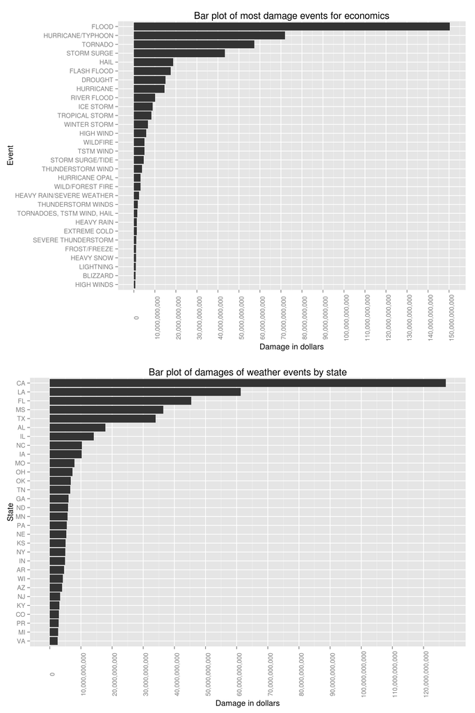

```r
multiplot(p3, p4, cols = 1)
```